# Tutorial: Point Emission Data

10/10/2020

In this tutorial, we will demonstrate how to represent PM 2.5 point emission data on maps. As an example, we will look at the PM 2.5 data for four states - Illinois, Indiana, Wisconsin, and Michigan. The goal of this exercise is to create a point data map that provides a clear visualization of the point source of PM 2.5 emission.

# Loading Packages and Data

We start by loading the necessary packages - tidyverse, sf, and tmap. Tidyverse is a system of packages for data manipulation and is frequently utilized in statistical analyses. Sf is a package that offers a standardized way to encode spatial vector data in R. Lastly, tmap allows us to generate and customize a variety of maps, although we will only use it to create a simple point data map in the tutorial.

```r
library(tidyverse)
library(sf)
library(tmap)
```

Besides the packages, we also need to load our data, and we call the data frame `pe1`.

```r
#Read in data
pe1 <- read_csv("process_12345.csv")
```

# Data Manipulation

The dataset comes from 2014 National Emissions Inventory, which is “a comprehensive and detailed estimate of air emissions of criteria pollutants, criteria precursors, and hazardous air pollutants from air emissions sources.” You can read more about this dataset on this [website](https://www.epa.gov/air-emissions-inventories/national-emissions-inventory-nei).

```r
states.abbr <- c("IL", "IN", "WI", "MI")

#Filter for states
fourstate.pe <- pe1 %>%
        filter(state %in% states.abbr)
```

Next, we turn our focus to the pollutant data. To familiarize ourselves with the variable `pollutant desc`, we use the `unique` function to examine all the unique values of this variable.

```r
#Find pollutant names for pm2.5
unique(fourstate.pe$`pollutant desc`)
```

```
##   [1] "Hexane"
##   [2] "Toluene"
##   [3] "Propionaldehyde"
##   [4] "Xylenes (Mixed Isomers)"
##   [5] "Benzo[g,h,i,]Perylene"
##   [6] "Indeno[1,2,3-c,d]Pyrene"
##   [7] "Benzo[b]Fluoranthene"
##   [8] "Fluoranthene"
##   [9] "Benzo[k]Fluoranthene"
##  [10] "Acenaphthylene"
##  [11] "Chrysene"
##  [12] "Formaldehyde"
##  [13] "Benzo[a]Pyrene"
##  [14] "2,2,4-Trimethylpentane"
##  [15] "Benz[a]Anthracene"
```

[output cut: 187 more lines]

We see that there are quite a number of different pollutants, but we are primarily interested in the PM 2.5 data. Therefore, we use the `filter` function again to subset the data, retaining only those observations with the pollutant being “PM2.5 Filterable” or “PM2.5 Primary (Filt + Cond)”.

```r
pm25 <- c("PM2.5 Filterable",  "PM2.5 Primary (Filt + Cond)")

#Filter for pm2.5
fourstate.pm <- fourstate.pe %>%
        filter(`pollutant desc` %in% pm25)
```

Now we will take care of the duplicates and missing values, both of which should be removed from our data. The following line of code eliminates any duplicated values in `eis facility id`.

```r
#remove duplicates
fourstate.pm.final <- fourstate.pm[!duplicated(fourstate.pm$`eis facility id`),]
```

The following line of code eliminates any missing values in `site latitude`. We call this cleaned data frame `fourstate.pm.final`.

```r
#remove na coords
fourstate.pm.final <- fourstate.pm.final[!is.na(fourstate.pm.final$`site latitude`),]
```

The last step in the data manipulation process is to turn our data points into a spatial object, which we can accomplish by using the `st_as_sf` function. Notice that we use the coordinate reference system 4326, which is the geodetic coordinate system for world. More information about coordinate reference systems can be found on this [website](https://epsg.io).

```r
#Turn into sf object
fourstate.pm.spatial <- st_as_sf(fourstate.pm.final, coords = c("site longitude", "site latitude"), crs = 4326)
```

# Making Point Data Maps

At this point, we only have the point data for the source of PM 2.5 emission. To make a map, however, we also need to load the shapefile for the four states that we are analyzing.

```r
fourstates <- st_read("FourStates")
```

Finally, we are ready to make a map! The command for generating a point data map is actually quite easy. We just need to specify the shapefile that stores the shape of the states and the point data which we have turned into a spatial object earlier. For aesthetic purpose, we adjust the size of the dots to 0.01 so that the pattern of those points is discernible.

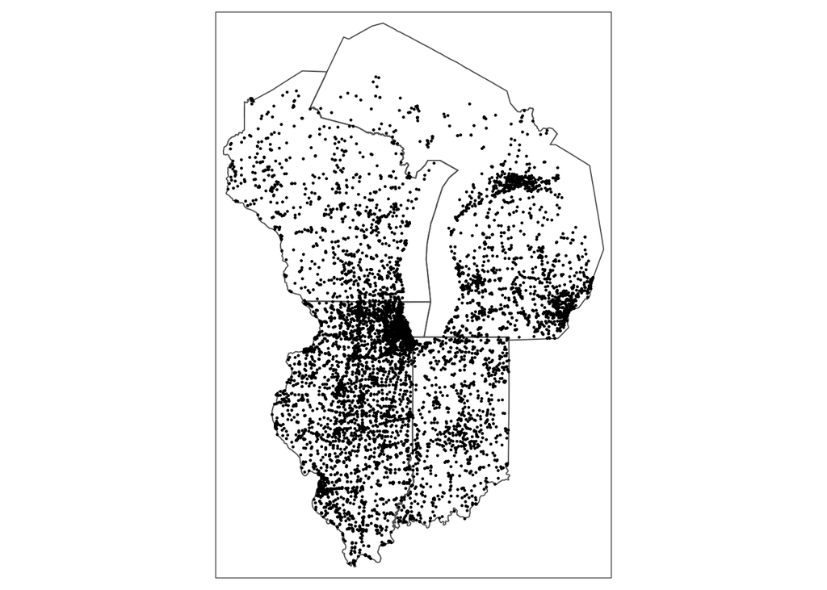

```r
tm_shape(fourstates) +
        tm_borders() +
        tm_shape(fourstate.pm.spatial) +
        tm_dots(size = 0.01)
```

This completes our tutorial. Following the simple steps above would allow you to create a simple point data map, which is often a neat and easily interpretable visualization of the spatial data that we seek to analyze.